# Lesson 5

### Multivariate Data

Notes:

### Moira Perceived Audience Size Colored by Age

Notes:

### Third Qualitative Variable

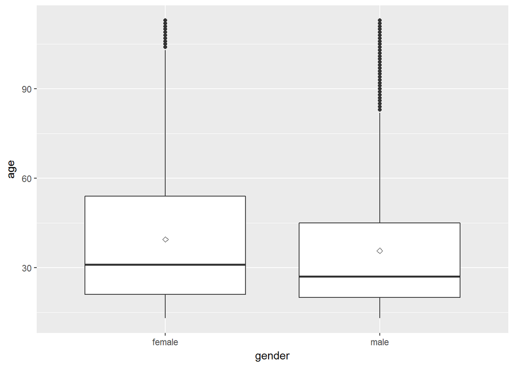

```r
library(ggplot2)
pf <- read.csv('pseudo_facebook.tsv', sep = '\t')
ggplot(aes(x = gender, y = age),
       data = subset(pf, !is.na(gender))) + geom_boxplot() +
  stat_summary(fun.y=mean, geom='point', shape =5 )
```

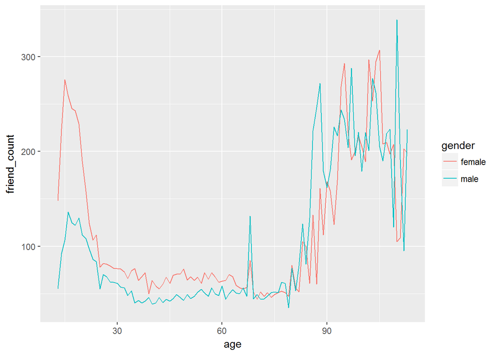

```r
ggplot(aes(x = age, y = friend_count),
       data = subset(pf, !is.na(gender))) +
  geom_line(aes(color=gender), stat='summary', fun.y=median)
```

### Plotting Conditional Summaries

Notes: # Write code to create a new data frame, # called ‘pf.fc_by_age_gender’, that contains # information on each age AND gender group.

# The data frame should contain the following variables:

# n (the number of users in each age and gender grouping)

```r
library(dplyr)
age_gender_groups <- group_by(subset(pf, !is.na(gender)), age, gender)
pf.fc_by_age_gender <- summarise(age_gender_groups,
                                 mean_friend_count=mean(friend_count),
                                 median_friend_count=median(friend_count),
                                 n=n())
pf.fc_by_age_gender <- arrange(pf.fc_by_age_gender, age)
head(pf.fc_by_age_gender)
```

```
## Source: local data frame [6 x 5]
## Groups: age [3]
##
##     age gender mean_friend_count median_friend_count     n
##   <int> <fctr>             <dbl>               <dbl> <int>
## 1    13 female          259.1606               148.0   193
## 2    13   male          102.1340                55.0   291
## 3    14 female          362.4286               224.0   847
## 4    14   male          164.1456                92.5  1078
## 5    15 female          538.6813               276.0  1139
## 6    15   male          200.6658               106.5  1478
```

```r
tail(pf.fc_by_age_gender)
```

```
## Source: local data frame [6 x 5]
## Groups: age [3]
##
##     age gender mean_friend_count median_friend_count     n
##   <int> <fctr>             <dbl>               <dbl> <int>
## 1   111 female          244.4286               109.0     7
## 2   111   male          246.5000               191.5    10
## 3   112 female          201.2000               203.0     5
## 4   112   male          594.0769                95.0    13
## 5   113 female          278.6571               198.0   105
## 6   113   male          410.3956               223.0    91
```

```r
#Solving with chained commands
pf.fc_by_age_gender1 <- pf %>%
  filter(!is.na(gender)) %>%
  group_by(age, gender) %>%
  summarise(mean_friend_count=mean(friend_count),
            median_friend_count=median(friend_count),
            n=n()) %>%
  ungroup() %>% #Summarise removes one layer of grouping when it runs, gender is removed, so ungroup 1 more time to remove age layer
  arrange(age)
head(pf.fc_by_age_gender1)
```

```
## # A tibble: 6 × 5
##     age gender mean_friend_count median_friend_count     n
##   <int> <fctr>             <dbl>               <dbl> <int>
## 1    13 female          259.1606               148.0   193
## 2    13   male          102.1340                55.0   291
## 3    14 female          362.4286               224.0   847
## 4    14   male          164.1456                92.5  1078
## 5    15 female          538.6813               276.0  1139
## 6    15   male          200.6658               106.5  1478
```

```r
tail(pf.fc_by_age_gender1)
```

```
## # A tibble: 6 × 5
##     age gender mean_friend_count median_friend_count     n
##   <int> <fctr>             <dbl>               <dbl> <int>
## 1   111 female          244.4286               109.0     7
## 2   111   male          246.5000               191.5    10
## 3   112 female          201.2000               203.0     5
## 4   112   male          594.0769                95.0    13
## 5   113 female          278.6571               198.0   105
## 6   113   male          410.3956               223.0    91
```

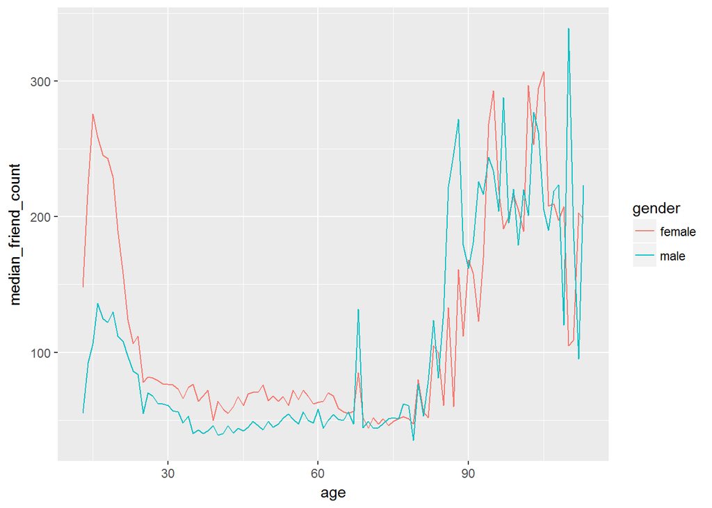

```r
# Create a line graph showing the
# median friend count over the ages
# for each gender. Be sure to use
# the data frame you just created,
# pf.fc_by_age_gender.
ggplot(aes(x = age, y = median_friend_count),
              data = subset(pf.fc_by_age_gender1)) +
  geom_line(aes(color = gender), stat = 'summary', fun.y = median)
```

### Thinking in Ratios

Notes:

### Wide and Long Format

Notes: Long format, there is a row for each gender Wide format, make 2 columns for gender (so half the rows than Long) ***

### Reshaping Data

Notes: Functions used speread dcast/acast melt

```r
#install.packages('reshape2')
library(reshape2)
library(tidyr)
#using dplyr-tidyr
spread(subset(pf.fc_by_age_gender, select = c('gender', 'age', 'median_friend_count')), gender, median_friend_count)
```

```
## Source: local data frame [101 x 3]
## Groups: age [101]
##
##      age female  male
## *  <int>  <dbl> <dbl>
## 1     13  148.0  55.0
## 2     14  224.0  92.5
## 3     15  276.0 106.5
## 4     16  258.5 136.0
## 5     17  245.5 125.0
## 6     18  243.0 122.0
## 7     19  229.0 130.0
## 8     20  190.0 112.0
## 9     21  158.0 108.0
## 10    22  124.0  97.0
## # ... with 91 more rows
```

```r
#using reshape
pf.fc_by_age_gender.wide <- dcast( #dcast for dataframe, acast for vector/array
                          pf.fc_by_age_gender,
                          age ~ gender,
                          value.var = 'median_friend_count')
head(pf.fc_by_age_gender.wide)
```

```
##   age female  male
## 1  13  148.0  55.0
## 2  14  224.0  92.5
## 3  15  276.0 106.5
## 4  16  258.5 136.0
## 5  17  245.5 125.0
## 6  18  243.0 122.0
```

```r
#melt function converts from wide to long format
```

### Ratio Plot

Notes: # Plot the ratio of the female to male median # friend counts using the data frame # pf.fc_by_age_gender.wide.

# Think about what geom you should use.

# Add a horizontal line to the plot with

# a y intercept of 1, which will be the

# base line. Look up the documentation

# for geom_hline to do that. Use the parameter

# linetype in geom_hline to make the

# line dashed.

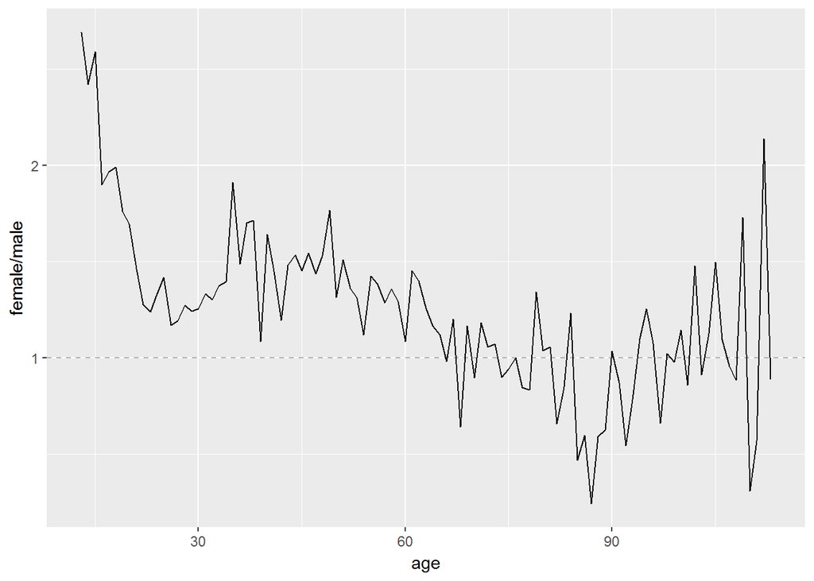

```r
ggplot(aes(x=age, y=female/male), data=pf.fc_by_age_gender.wide) +
  geom_line() +
  geom_hline(yintercept = 1, alpha=0.3, linetype=2)
```

### Third Quantitative Variable

Notes: year_joined based on tenure (in days)

```r
pf$year_joined <- floor(2014 - pf$tenure/365)
summary(pf$year_joined)
```

```
##    Min. 1st Qu.  Median    Mean 3rd Qu.    Max.    NA's
##    2005    2012    2012    2012    2013    2014       2
```

```r
table(pf$year_joined)
```

```
##
##  2005  2006  2007  2008  2009  2010  2011  2012  2013  2014
##     9    15   581  1507  4557  5448  9860 33366 43588    70
```

### Cut a Variable

Notes: # Create a new variable in the data frame # called year_joined.bucket by using # the cut function on the variable year_joined.

# You need to create the following buckets for the

# new variable, year_joined.bucket

# (2004, 2009]

# (2009, 2011]

# (2011, 2012]

# (2012, 2014]

# Note that a parenthesis means exclude the year and a

# bracket means include the year.

```r
pf$year_joined.bucket=cut(pf$year_joined,
                          c(2004, 2009, 2011, 2012, 2014))
table(pf$year_joined.bucket)
```

```
##
## (2004,2009] (2009,2011] (2011,2012] (2012,2014]
##        6669       15308       33366       43658
```

```r
#cut samples
Z <- stats::rnorm(10000)
table(cut(Z, breaks = -6:6))
```

```
##
## (-6,-5] (-5,-4] (-4,-3] (-3,-2] (-2,-1]  (-1,0]   (0,1]   (1,2]   (2,3]
##       0       0      11     205    1398    3407    3410    1342     214
##   (3,4]   (4,5]   (5,6]
##      12       1       0
```

```r
sum(table(cut(Z, breaks = -6:6, labels = FALSE)))
```

```
## [1] 10000
```

```r
(graphics::hist(Z, breaks = -6:6, plot = FALSE)$counts)
```

```
##  [1]    0    0   11  205 1398 3407 3410 1342  214   12    1    0
```

```r
table(cut(Z, breaks=3*(-2:5), right=FALSE))
```

```
##
## [-6,-3)  [-3,0)   [0,3)   [3,6)   [6,9)  [9,12) [12,15)
##      11    5010    4966      13       0       0       0
```

### Plotting it All Together

Notes: # Create a line graph of friend_count vs. age # so that each year_joined.bucket is a line # tracking the median user friend_count across # age. This means you should have four different # lines on your plot.

```r
table(pf$year_joined.bucket, useNA='ifany')
```

```
##
## (2004,2009] (2009,2011] (2011,2012] (2012,2014]        <NA>
##        6669       15308       33366       43658           2
```

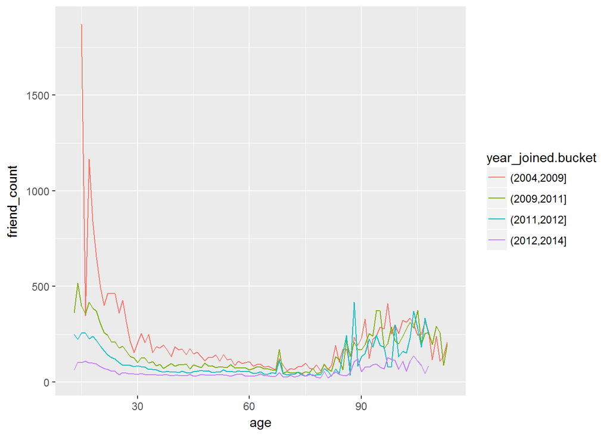

```r
ggplot(aes(x=age, y=friend_count),
           data=subset(pf, !is.na(year_joined.bucket))) +
  geom_line(aes(color=year_joined.bucket), stat='summary', fun.y=median)
```

### Plot the Grand Mean

Notes: # (1) Add another geom_line to code below # to plot the grand mean of the friend count vs age.

# (2) Exclude any users whose year_joined.bucket is NA.

# (3) Use a different line type for the grand mean.

# As a reminder, the parameter linetype can take the values 0-6:

# 0 = blank, 1 = solid, 2 = dashed

# 3 = dotted, 4 = dotdash, 5 = longdash

# 6 = twodash

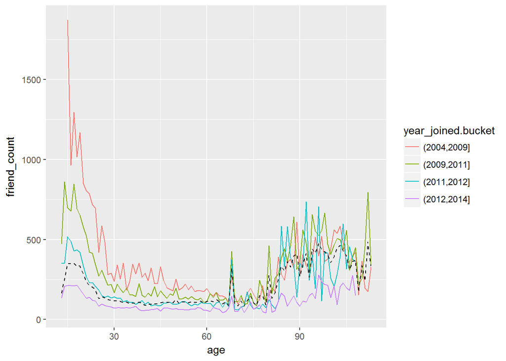

```r
ggplot(aes(x=age, y=friend_count),
           data=subset(pf, !is.na(year_joined.bucket))) +
  geom_line(aes(color=year_joined.bucket), stat='summary', fun.y=mean) +
  geom_line(stat='summary', fun.y=mean, linetype=2)
```

```r
#The grand mean line shows that much of the pattern is due to recent joinees
```

### Friending Rate

Notes:

```r
with(subset(pf, tenure>=1), summary(friend_count/tenure))
```

```
##     Min.  1st Qu.   Median     Mean  3rd Qu.     Max.
##   0.0000   0.0775   0.2205   0.6096   0.5658 417.0000
```

### Friendships Initiated

Notes:

What is the median friend rate? 0.22 What is the maximum friend rate? 417

### Bias-Variance Tradeoff Revisited

Notes: # Create a line graph of mean of friendships_initiated per day (of tenure) # vs. tenure colored by year_joined.bucket.

# You need to make use of the variables tenure,

# friendships_initiated, and year_joined.bucket.

# You also need to subset the data to only consider user with at least

# one day of tenure.

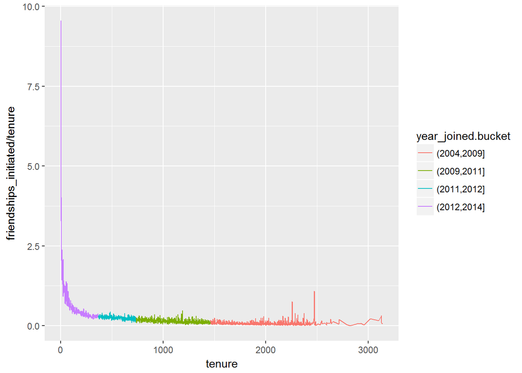

```r
#People with more tenure initiate less friendships
ggplot(aes(x = tenure, y = friendships_initiated / tenure),
       data = subset(pf, tenure >= 1)) +
  geom_line(aes(color = year_joined.bucket),
            stat = 'summary',
            fun.y = mean)
```

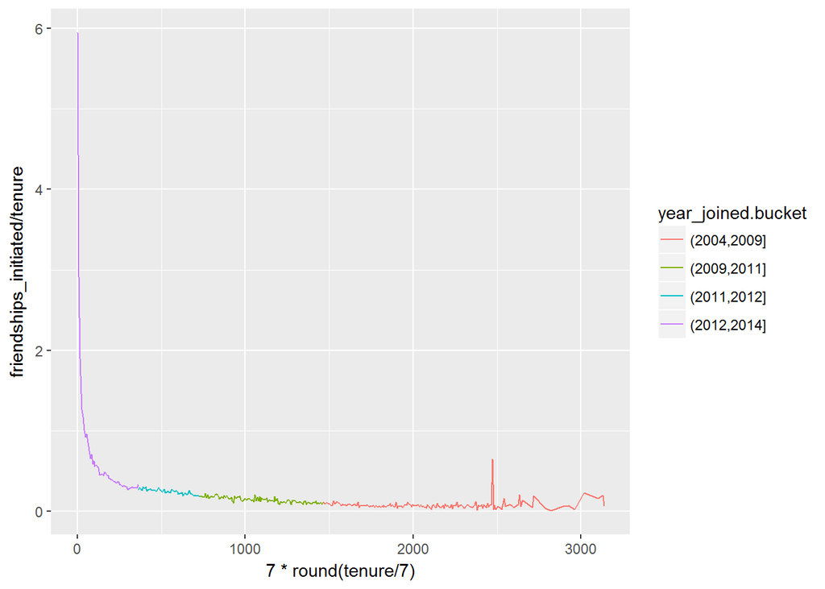

```r
#Smoothing the curve to remove noise (by binning the x axis differently)
ggplot(aes(x = 7 * round(tenure / 7), y = friendships_initiated / tenure),
       data = subset(pf, tenure > 0)) +
  geom_line(aes(color = year_joined.bucket),
            stat = "summary",
            fun.y = mean)
```

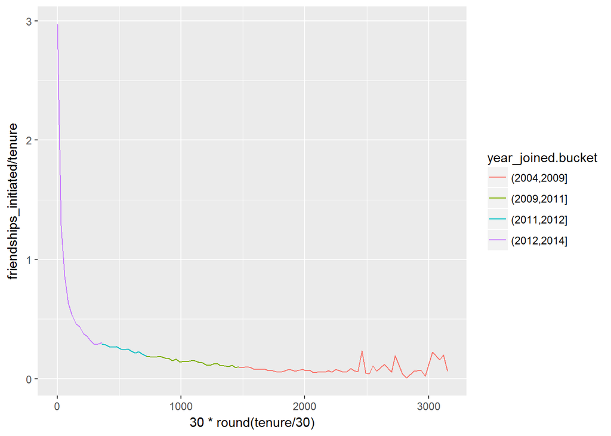

```r
ggplot(aes(x = 30 * round(tenure / 30), y = friendships_initiated / tenure),
       data = subset(pf, tenure > 0)) +
  geom_line(aes(color = year_joined.bucket),
            stat = "summary",
            fun.y = mean)
```

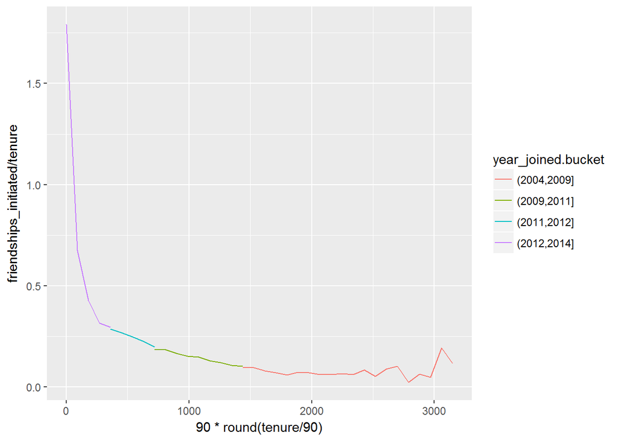

```r
ggplot(aes(x = 90 * round(tenure / 90), y = friendships_initiated / tenure),
       data = subset(pf, tenure > 0)) +
  geom_line(aes(color = year_joined.bucket),
            stat = "summary",
            fun.y = mean)
```

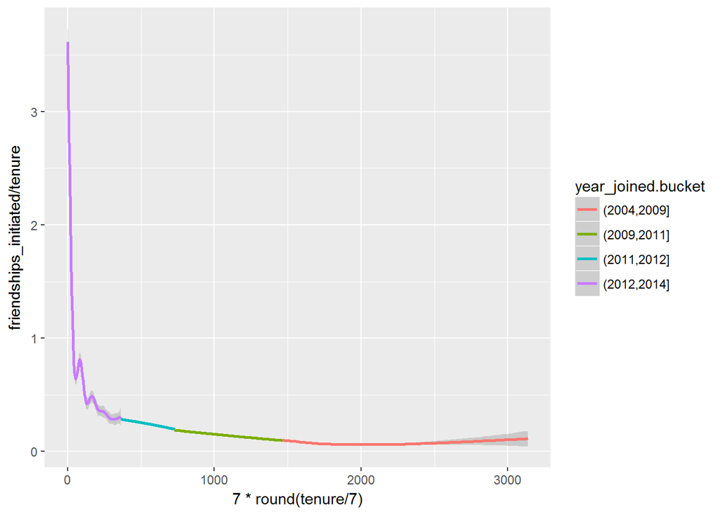

```r
ggplot(aes(x = 7 * round(tenure / 7), y = friendships_initiated / tenure),
       data = subset(pf, tenure > 0)) +
  geom_smooth(aes(color = year_joined.bucket))
```

### Sean’s NFL Fan Sentiment Study

Notes:

### Introducing the Yogurt Data Set

Notes:

### Histograms Revisited

Notes: Discreteness in the distribution, some prices have a distribution while others don’t

```r
yo <- read.csv('yogurt.csv')
str(yo)
```

```
## 'data.frame':    2380 obs. of  9 variables:
##  $ obs        : int  1 2 3 4 5 6 7 8 9 10 ...
##  $ id         : int  2100081 2100081 2100081 2100081 2100081 2100081 2100081 2100081 2100081 2100081 ...
##  $ time       : int  9678 9697 9825 9999 10015 10029 10036 10042 10083 10091 ...
##  $ strawberry : int  0 0 0 0 1 1 0 0 0 0 ...
##  $ blueberry  : int  0 0 0 0 0 0 0 0 0 0 ...
##  $ pina.colada: int  0 0 0 0 1 2 0 0 0 0 ...
##  $ plain      : int  0 0 0 0 0 0 0 0 0 0 ...
##  $ mixed.berry: int  1 1 1 1 1 1 1 1 1 1 ...
##  $ price      : num  59 59 65 65 49 ...
```

```r
summary(yo)
```

```
##       obs               id               time         strawberry
##  Min.   :   1.0   Min.   :2100081   Min.   : 9662   Min.   : 0.0000
##  1st Qu.: 696.5   1st Qu.:2114348   1st Qu.: 9843   1st Qu.: 0.0000
##  Median :1369.5   Median :2126532   Median :10045   Median : 0.0000
##  Mean   :1367.8   Mean   :2128592   Mean   :10050   Mean   : 0.6492
##  3rd Qu.:2044.2   3rd Qu.:2141549   3rd Qu.:10255   3rd Qu.: 1.0000
##  Max.   :2743.0   Max.   :2170639   Max.   :10459   Max.   :11.0000
##    blueberry        pina.colada          plain         mixed.berry
##  Min.   : 0.0000   Min.   : 0.0000   Min.   :0.0000   Min.   :0.0000
##  1st Qu.: 0.0000   1st Qu.: 0.0000   1st Qu.:0.0000   1st Qu.:0.0000
##  Median : 0.0000   Median : 0.0000   Median :0.0000   Median :0.0000
##  Mean   : 0.3571   Mean   : 0.3584   Mean   :0.2176   Mean   :0.3887
##  3rd Qu.: 0.0000   3rd Qu.: 0.0000   3rd Qu.:0.0000   3rd Qu.:0.0000
##  Max.   :12.0000   Max.   :10.0000   Max.   :6.0000   Max.   :8.0000
##      price
##  Min.   :20.00
##  1st Qu.:50.00
##  Median :65.04
##  Mean   :59.25
##  3rd Qu.:68.96
##  Max.   :68.96
```

```r
yo$id <- factor(yo$id)
str(yo)
```

```
## 'data.frame':    2380 obs. of  9 variables:
##  $ obs        : int  1 2 3 4 5 6 7 8 9 10 ...
##  $ id         : Factor w/ 332 levels "2100081","2100370",..: 1 1 1 1 1 1 1 1 1 1 ...
##  $ time       : int  9678 9697 9825 9999 10015 10029 10036 10042 10083 10091 ...
##  $ strawberry : int  0 0 0 0 1 1 0 0 0 0 ...
##  $ blueberry  : int  0 0 0 0 0 0 0 0 0 0 ...
##  $ pina.colada: int  0 0 0 0 1 2 0 0 0 0 ...
##  $ plain      : int  0 0 0 0 0 0 0 0 0 0 ...
##  $ mixed.berry: int  1 1 1 1 1 1 1 1 1 1 ...
##  $ price      : num  59 59 65 65 49 ...
```

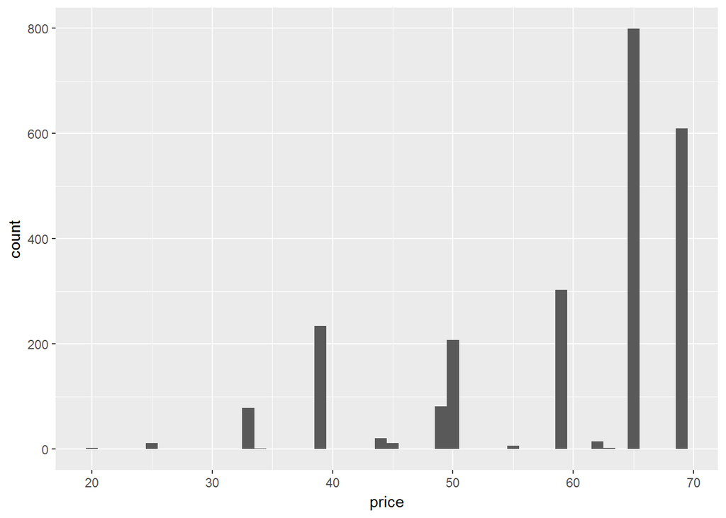

```r
ggplot(data = yo, aes(x = price)) +
  geom_histogram(binwidth = 1)
```

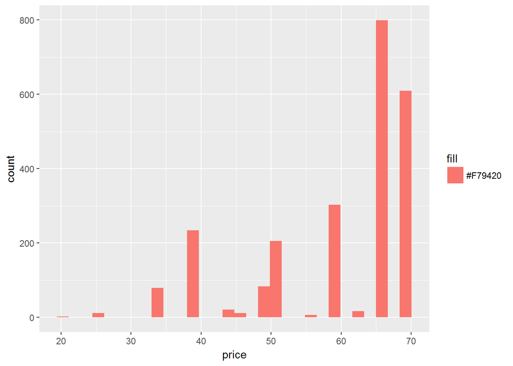

```r
qplot(data=yo, x=price, fill='#F79420')
```

### Number of Purchases

Notes: Discreteness can be observed by looking at unique prices, 20 are there

# Create a new variable called all.purchases,

# which gives the total counts of yogurt for

# each observation or household.

# One way to do this is using the transform

# function. You can look up the function transform

# and run the examples of code at the bottom of the

# documentation to figure out what it does.

# The transform function produces a data frame

# so if you use it then save the result to ‘yo’!

```r
length(unique(yo$price))
```

```
## [1] 20
```

```r
table(yo$price) #also gives an idea of distribution
```

```
##
##    20 24.96 33.04  33.2 33.28 33.36 33.52 39.04    44 45.04 48.96 49.52
##     2    11    54     1     1    22     1   234    21    11    81     1
##  49.6    50 55.04 58.96    62 63.04 65.04 68.96
##     1   205     6   303    15     2   799   609
```

```r
yo <- transform(yo, all.purchases=(strawberry + blueberry + pina.colada + mixed.berry + plain))
summary(yo$all.purchases)
```

```
##    Min. 1st Qu.  Median    Mean 3rd Qu.    Max.
##   1.000   1.000   2.000   1.971   2.000  21.000
```

### Prices over Time

Notes: # Create a scatterplot of price vs time.

# This will be an example of a time series plot.

# Resolve overplotting issues by using

# techniques you learned in Lesson 4.

Most common prices seem to be increasing over time. some lower prices may be due to sales/coupons

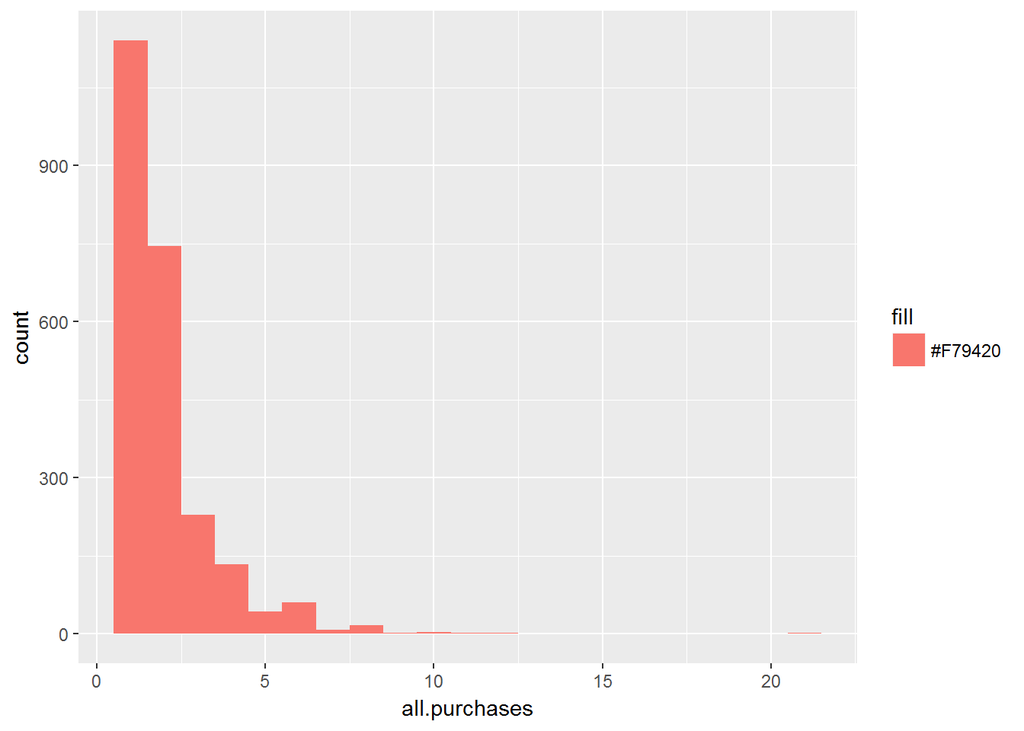

```r
qplot(data=yo, x=all.purchases, fill='#F79420', binwidth=1)
```

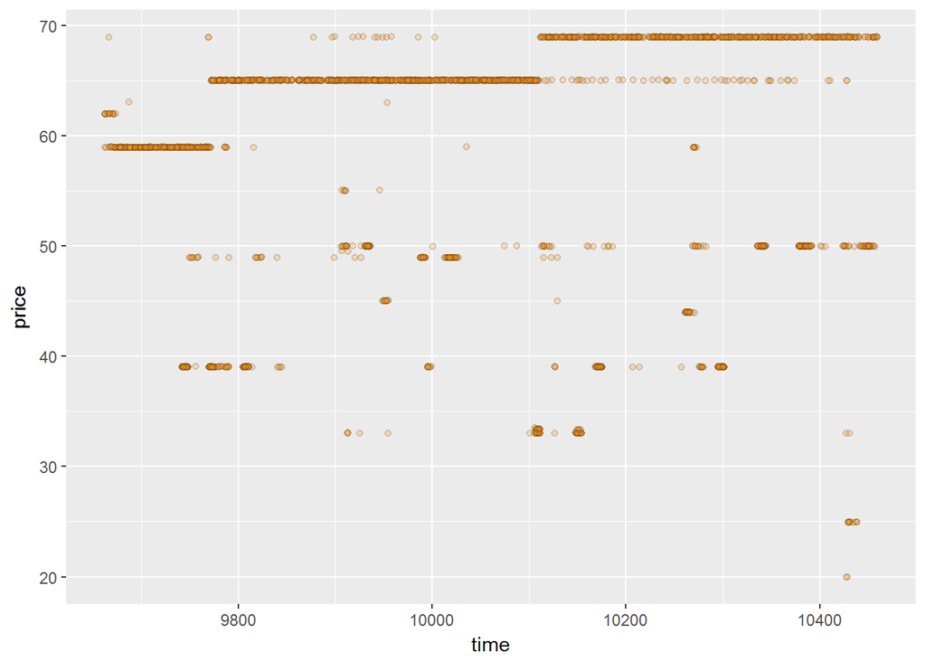

```r
ggplot(aes(x=time, y=price), data=yo) +
  geom_jitter(alpha=0.25, shape=21, fill = I('#F79420'))
```

### Sampling Observations

Notes: This data has Multiple observations of the same unit, work with a sample of those units to display raw data easily for that sample. Look at small set of households in more detail. ***

### Looking at Samples of Households

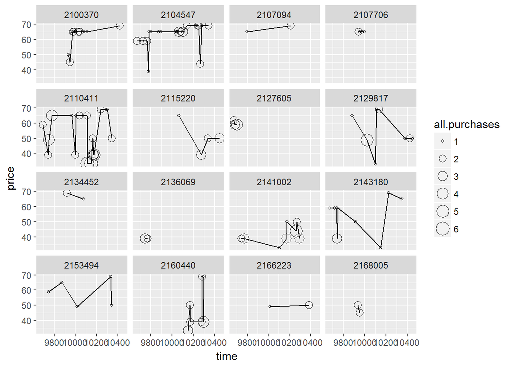

```r
set.seed(2324)
sample.ids <- sample(levels(yo$id), 16)
#%in% selects only those ids, in the sample.ids
ggplot(aes(x=time, y=price), data=subset(yo, id %in% sample.ids)) +
  facet_wrap( ~ id) +
  geom_line() +
  geom_point(aes(size = all.purchases), pch = 1)
```

### The Limits of Cross Sectional Data

Notes:

### Many Variables

Notes:

### Scatterplot Matrix

Notes: Categorical variables create faceted histograms, Continuous variables create scatter plots

```r
library(GGally)
theme_set(theme_minimal(20))
set.seed(1836)
pf_subset <- pf[,c(2:15)] #only variable indexes 2-15, 14 variables
names(pf)
```

```
##  [1] "userid"                "age"
##  [3] "dob_day"               "dob_year"
##  [5] "dob_month"             "gender"
##  [7] "tenure"                "friend_count"
##  [9] "friendships_initiated" "likes"
## [11] "likes_received"        "mobile_likes"
## [13] "mobile_likes_received" "www_likes"
## [15] "www_likes_received"    "year_joined"
## [17] "year_joined.bucket"
```

```r
names(pf_subset)
```

```
##  [1] "age"                   "dob_day"
##  [3] "dob_year"              "dob_month"
##  [5] "gender"                "tenure"
##  [7] "friend_count"          "friendships_initiated"
##  [9] "likes"                 "likes_received"
## [11] "mobile_likes"          "mobile_likes_received"
## [13] "www_likes"             "www_likes_received"
```

[figure not shown]

```r
ggpairs(pf_subset[sample.int(nrow(pf_subset),1000),])
```

```r
  #use axisLabels = 'internal' to have labels inside the plot
```

### Even More Variables

Notes:

### Heat Maps

Notes:

```r
nci <- read.table("nci.tsv")
colnames(nci) <- c(1:64)
```

```r
nci.long.samp <- melt(as.matrix(nci[1:200,]))
names(nci.long.samp) <- c("gene", "case", "value")
head(nci.long.samp)
```

```
##   gene case  value
## 1    1    1  0.300
## 2    2    1  1.180
## 3    3    1  0.550
## 4    4    1  1.140
## 5    5    1 -0.265
## 6    6    1 -0.070
```

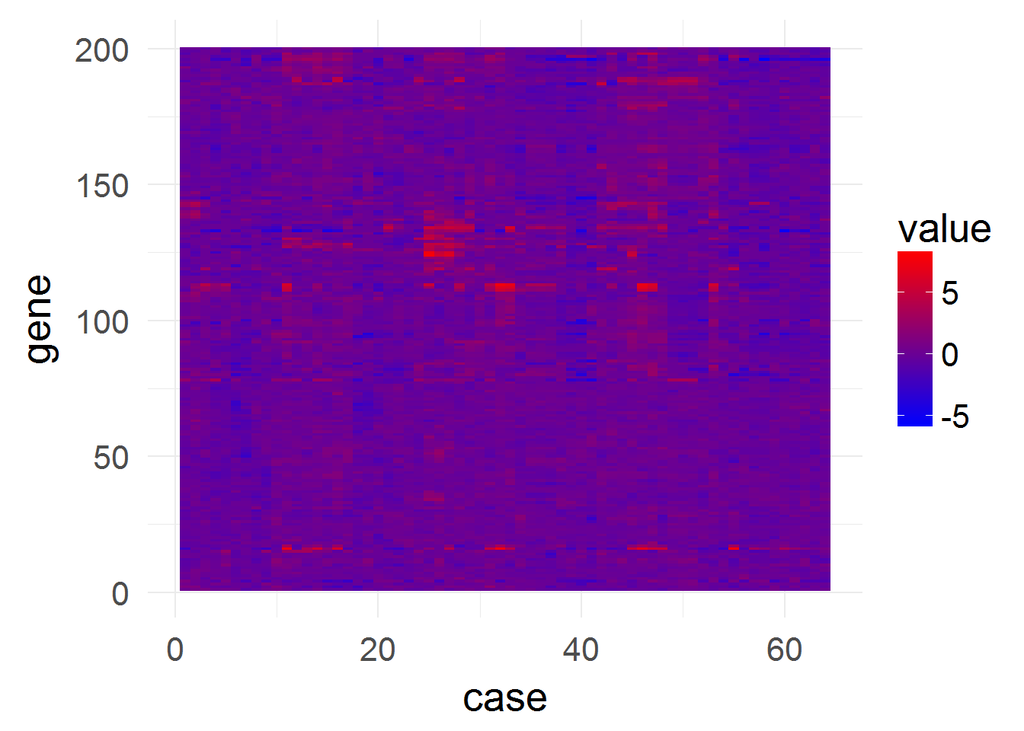

```r
ggplot(aes(y = gene, x = case, fill = value),
  data = nci.long.samp) +
  geom_tile() +
  scale_fill_gradientn(colours = colorRampPalette(c("blue", "red"))(100))
```

### Analyzing Three of More Variables

Reflection:

Click **KnitHTML** to see all of your hard work and to have an html page of this lesson, your answers, and your notes!